# Dynamic Network Analysis

An Introduction

Björn Siepe

bjoern.siepe@uni-marburg.de

Psychological Methods Lab, University of Marburg

October 23, 2024

## Materials and Goals

Slides at bsiepe.github.io/workshops

[figure not shown]

1. Understand advantages and structure of time series data and dynamic networks
2. Interpret dynamic networks
3. Get to know core assumptions, evidence, and limitations
4. Learn about new developments and future research topics

## What we don’t cover (in detail)

1. Planning of longitudinal studies
2. Panel Data
3. Data and preprocessing (very important)
4. Clinical theory

## Hype Cycle

[figure not shown]

[Jeremykemp, Wikimedia](https://commons.wikimedia.org/wiki/File:Gartner_Hype_Cycle.svg)

# Dynamic Networks

## General principles

- Dynamic associations within individuals
- Across time points and at the same time frames
- $n = 1$ (idiographic) and $n > 1$
- Commonly some form of vector autoregressive (VAR) model
- Often some sparsity

[figure not shown]

## Time Series Data

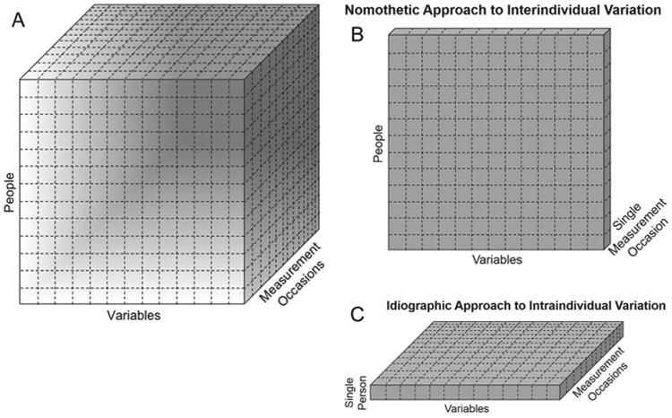

Beltz et al. (2016)

## Experience Sampling

[figure not shown]

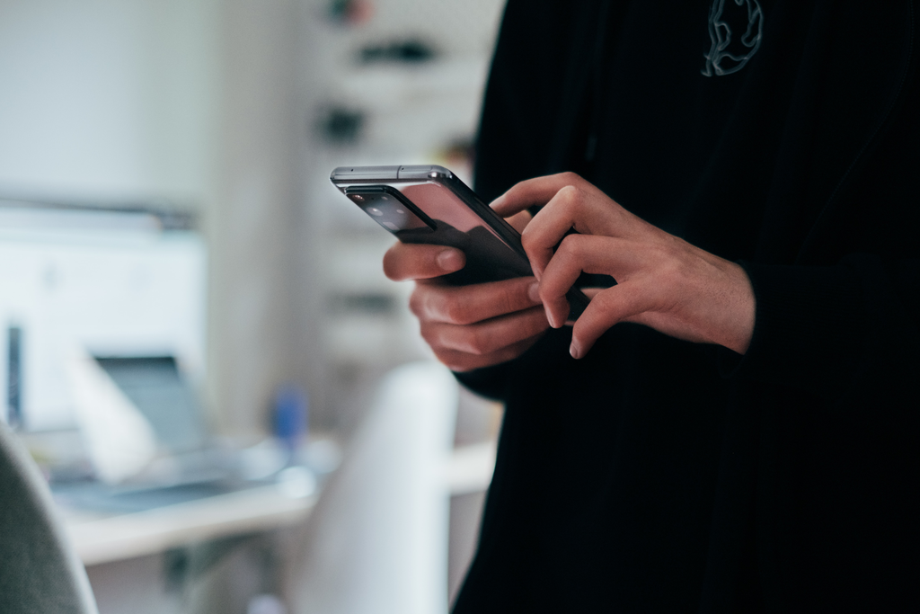

Sabina Ciesielska (Unsplash), Jonas Leupe (Unsplash)

## Autoregressive

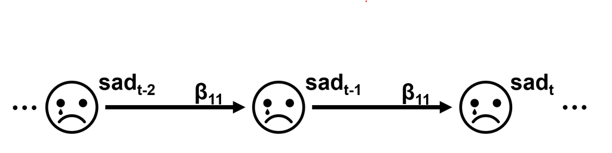

Next slides inspired by Julian Burger ([Link](https://osf.io/djm26))

## Autoregressive

[figure not shown]

## Cross-Lagged

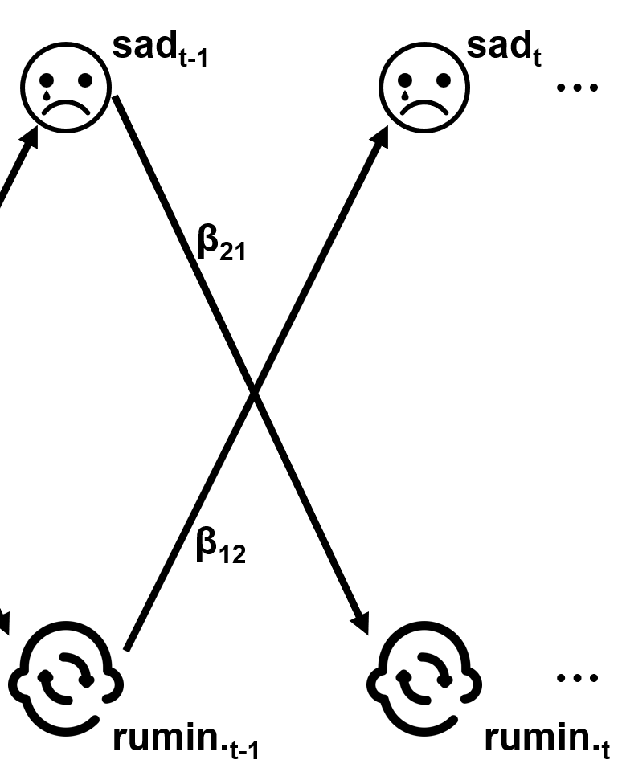

## Estimation of idiographic networks

**Model Equations**

More generally:
$$\color{darkred}{Y_{t}} = \color{blue}{\boldsymbol{B}} \color{darkred}{Y_{t-1}} + \color{orange}{\Sigma}$$

- Red: Data at current ($t$) and previous ($t-1$) time point
- Blue: Coefficients for autoregressive and cross-lagged effects
  - used for temporal effects
- Orange: Residuals/Innovations (in $\Sigma$ )
  - used for contemporaneous effects

## Maths Break

[figure not shown]

https://media.giphy.com/media/lHfxDepSGlzom6f65K/giphy.gif

## Intermediate Summary

- Networks are everywhere
- Almost any multivariate model can be a network
- A lot of cross-sectional studies with limited informativeness
- Longitudinal data allows for new insights
- Effects across time points and variables

# Interpreting dynamic networks

## Temporal Network

- Effect of variables on themselves and on others over time
- Directed effects
- Mostly: lag 1
- “Granger causality”

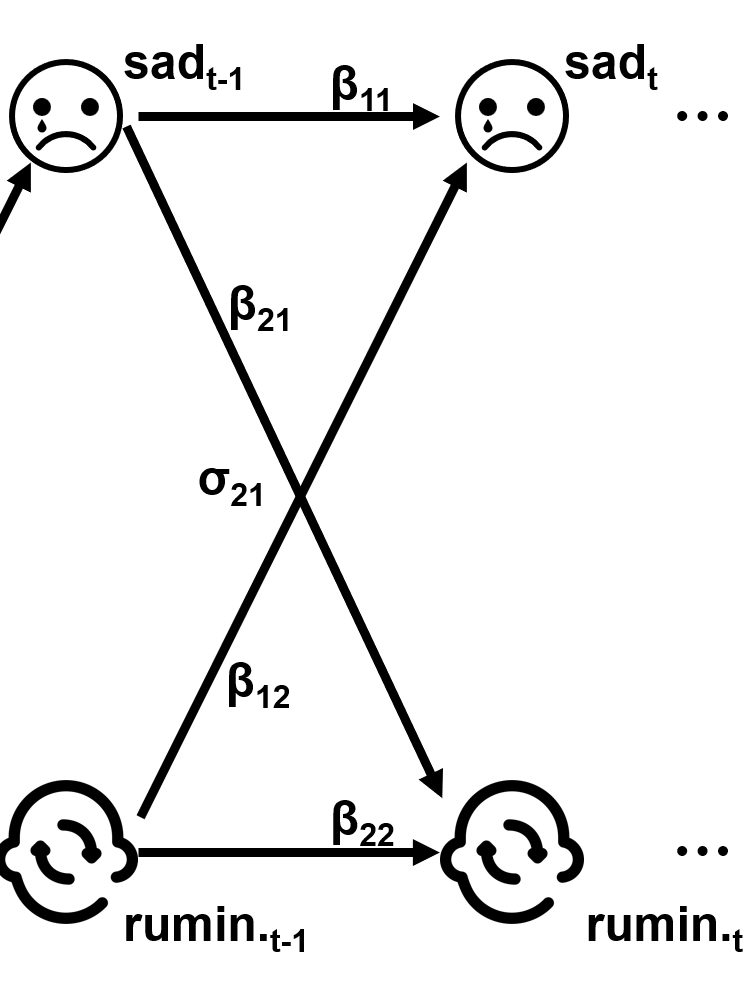

## “Contemporaneous” Network

- Partial correlation of residuals (innovations)
- undirected effects not captured by temporal network
- For example: effects faster than sampling frequency
- Example:
  $$Stress \rightarrow Expect\ Panic \rightarrow Fear$$

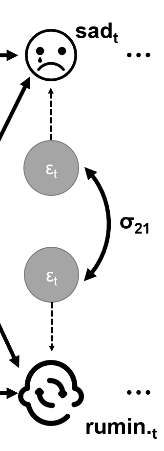

Example from Epskamp et al. (2018)

## Putting Things Together

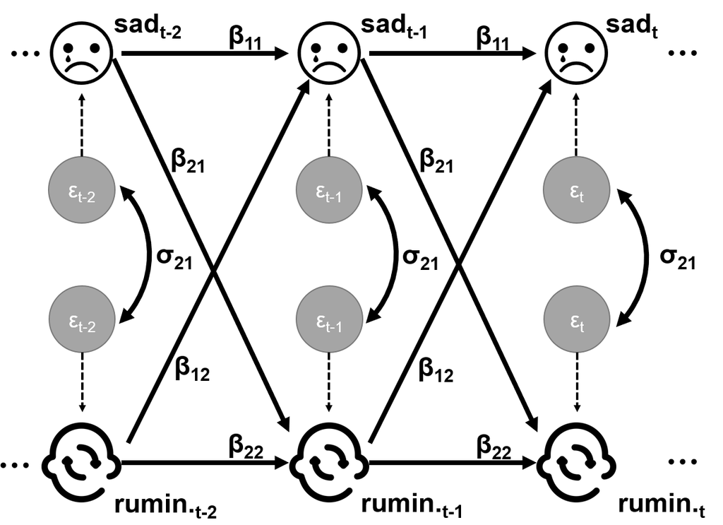

## Estimation

- large variety of estimation approaches:
  - Maximum Likelihood (`psychonetrics`)
  - State-Space Frameworks (`dynr`)
  - Continuous Time Models (`ctsem`)
  - Bayesian Estimation (`tsnet`)
- often induce sparsity via regularization or heuristics

[figure not shown]

## Example: Epskamp et al. (2018)

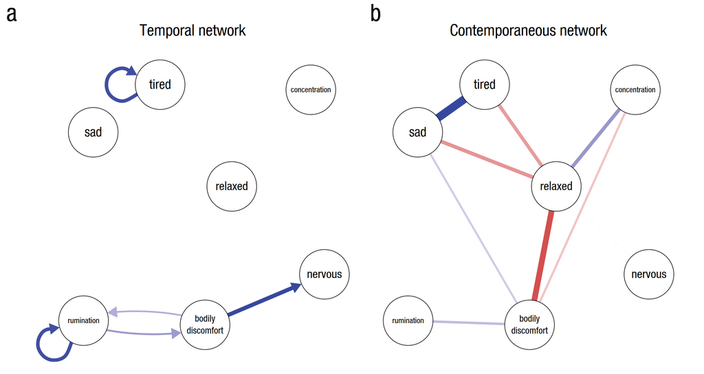

## $n >1$ Networks

- Often used: multilevel modeling
- Popular alternative: GIMME
- Advantages:
  - pool information from individuals
  - more power
  - Consideration of heterogeneity
  - fewer time points necessary
- `mlVAR` (Epskamp et al. 2018)
- `GIMME` (Beltz et al. 2016)
- `DSEM` (Hamaker et al. 2018)

Simple overview in Jordan, Winer, and Salem (2020)

## mlVAR and GIMME

**mlVAR**

- Borrow quantitative information
- Individual network parameters come from a shared probability distribution
- Parameters are “pulled together”
- “Between-person” network

**GIMME**

- Borrow qualitative information
- Individual networks, but partially common structure
- Group, subgroup, individual networks
- Heuristic algorithm

## Multilevel Example

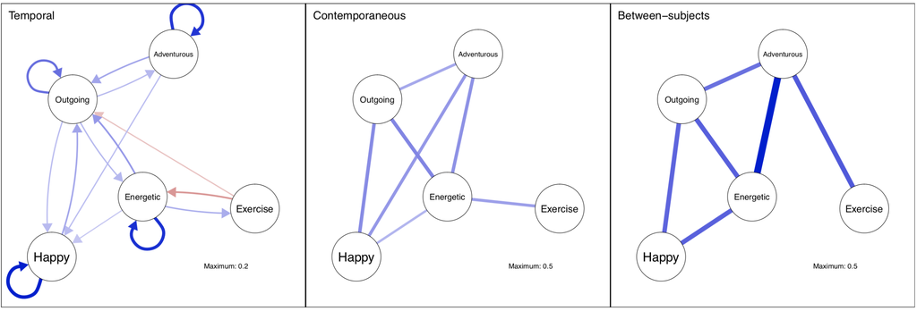

Epskamp et al. (2018)

## GIMME Example

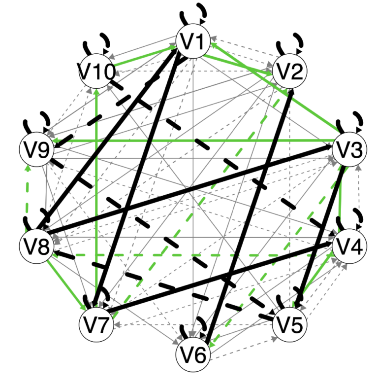

Taken from [GIMME homepage](https://tarheels.live/gimme/subgrouping-gimme/)

## Interpretation: Time Intervals

- Equal time intervals between measurements. Problem?
  - Night effect (Berkhout, Schuurman, and Hamaker 2024)

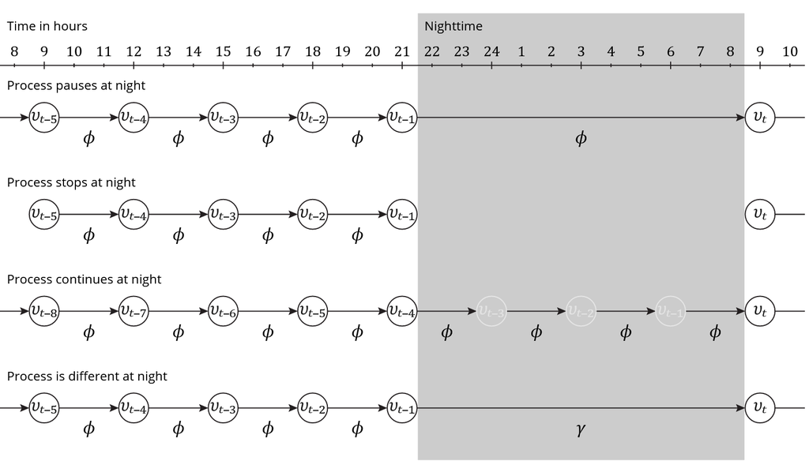

## Interpretation: Time Intervals

- Alternative: Continuous time (Ryan and Hamaker 2022)
- Correct time intervals for constructs to be measured
  - Stress vs. depression

## Interpretation: Change over Time

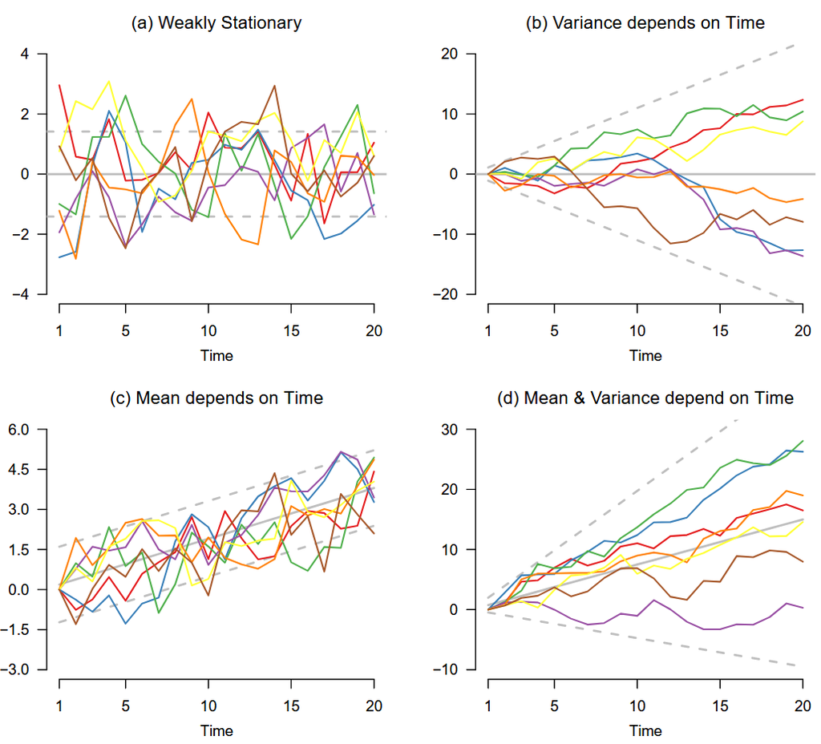

- Stationarity assumption: Means, variances, covariances are constant over time
- Realistic?

Ryan, Haslbeck, and Waldorp (2023)

## Interpretation: Change over Time

- Common solution: Some form of detrending, or modeling change over time (see later slides)
- Detrending: Remove change over time

[figure not shown]

## Interpretation: Other Stuff

- Causality
- Measurement (Bringmann et al. 2022)
- Variable selection
- Sparsity
- Missing data
- Distributional assumptions

## Optional: Practical Exercise

If time permits:

- Open file `dynamic_network_exercise.R`
- Work alone or in groups of 2-3

Google colab link (`.ipynb`)

[figure not shown]

## Optional: Practical Exercise Discussion

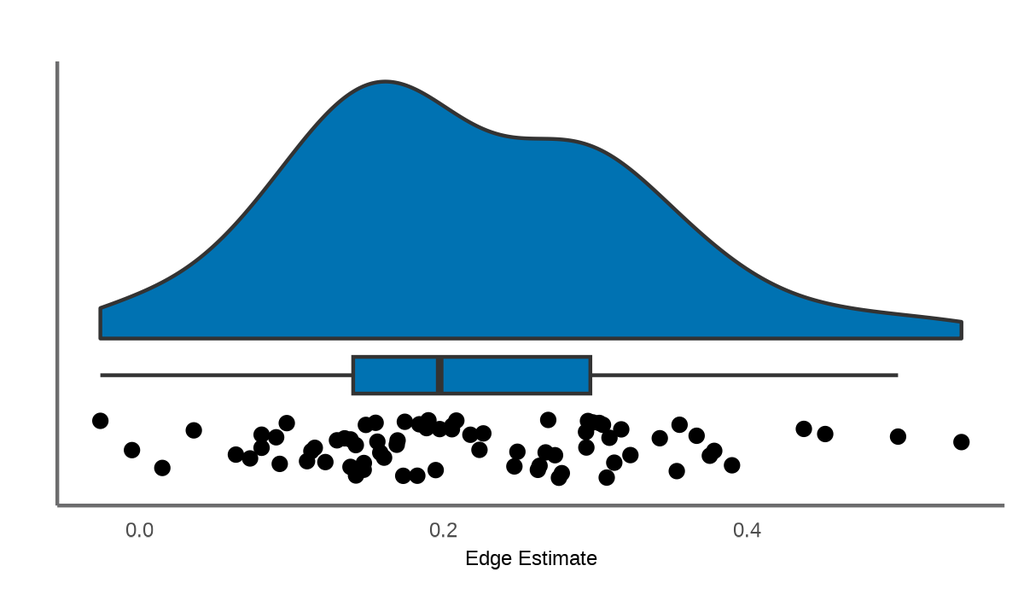

# Evidence and Pitfalls

## Topics to be covered

- Estimation Requirements
- Clinical Practice
- Density/Centrality
- Prediction

## Understanding Heterogeneity

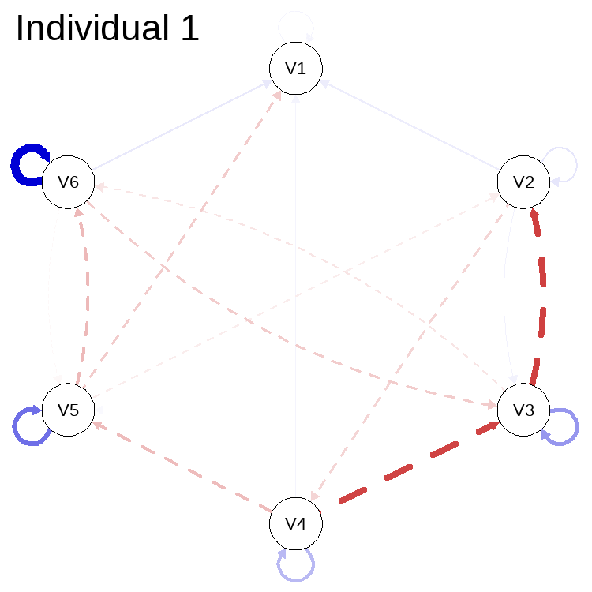

Hoekstra, Epskamp, and Borsboom (2022)

## Problem: Estimation Instability

```r
# Simulate 20 identical twins
for(i in 1:20){
  l_data[[i]] <-
    graphicalVAR::graphicalVARsim(
      nTime = 70,
      beta = person_1$beta,
      kappa = person_1$kappa
      )
# Fit network models
  l_fits[[i]] <- graphicalVAR(l_data[[i]])
}
```

[output not shown]

[figure not shown]

## Feasibility of Idiographic Networks

> The robustness of network results now firmly ranks as one of the field’s top priorities. (Marsman and Rhemtulla 2022)
- often only have vague rules of thumb
- Number of time points?
- Number of variables?
  - always think about number of paths to estimate!
  - idiographic gVAR:
    - 3 variables: $9 + 3 = 12$ parameters
    - 5 variables: $25 + 10 = 35$ parameters

Mansueto et al. (2023), Siepe et al. (2024)

## Solutions for Estimation Instability

- Tests to compare idiographic networks
  - Hoekstra, Epskamp, et al. (2024): R package `INIT` based on SEM
  - Siepe, Kloft & Heck (2024): R package `tsnet` based on Bayesian estimation
- With $n > 20$ (or so): Go multilevel/GIMME
  - Multilevel often outperforms $n = 1$, even if true model is idiographic (Lafit, Meers, and Ceulemans 2021)
- Sample size planning for $n = 1$ (Revol, Lafit, and Ceulemans 2024)

## Solutions for Estimation Instability

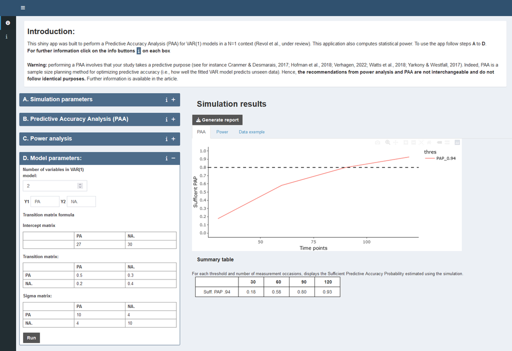

## Evidence in Clinical Practice

- Frumkin et al. (2021)
  - Few case studies
  - Patients more convinced than therapists
- Levinson et al. (2023)
  - n = 79, eating disorders
  - Module selection based on networks
- Hall et al. (2022)
  - Individual case study on TheraNET
  - Good example of detailed, network-based feedback
  - Apparently RCT planned
- No clear evidence
- Many different possibilities for use (Schumacher, Burger, et al. 2024)

## Recent developments

- Cooperation between therapist/patient and data
- Changes over time
- Prediction of therapy outcomes

## PECAN

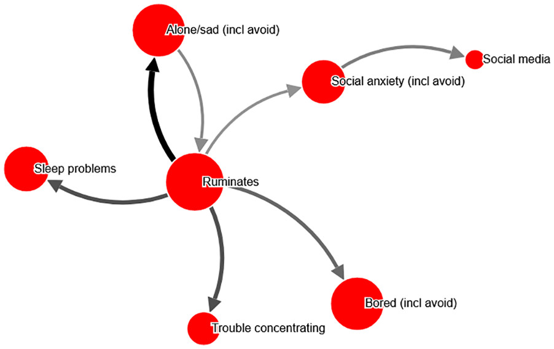

Klintwall, Bellander, and Cervin (2021)

## PREMISE

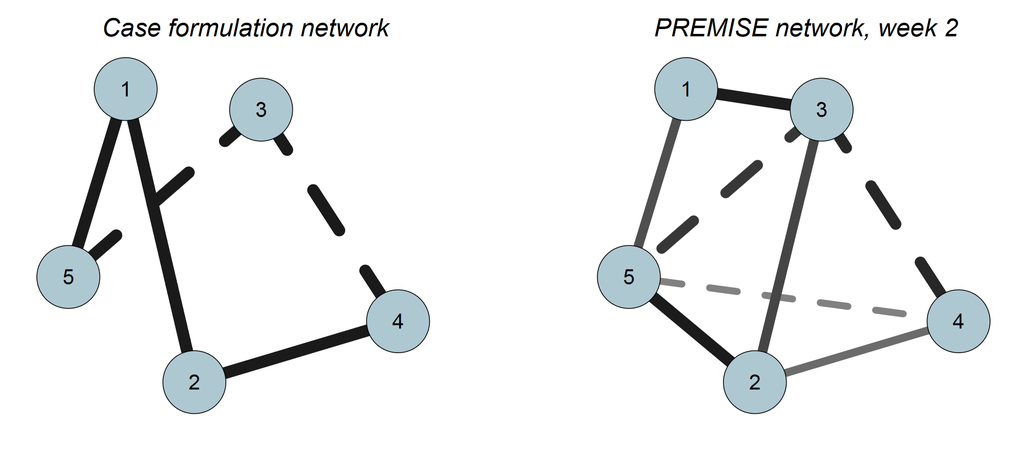

Burger et al. (2022), Burger et al. (2024), Björn S. Siepe, Kloft, and Heck (2024)

## Time varying networks

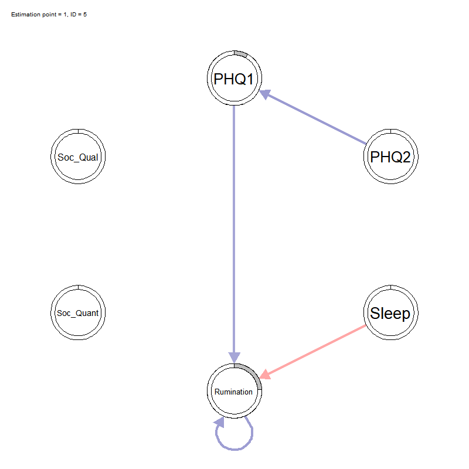

Siepe et al. (2024), Haslbeck, Bringmann, and Waldorp (2021), Scholten et al. (2023)

## Centrality/Density

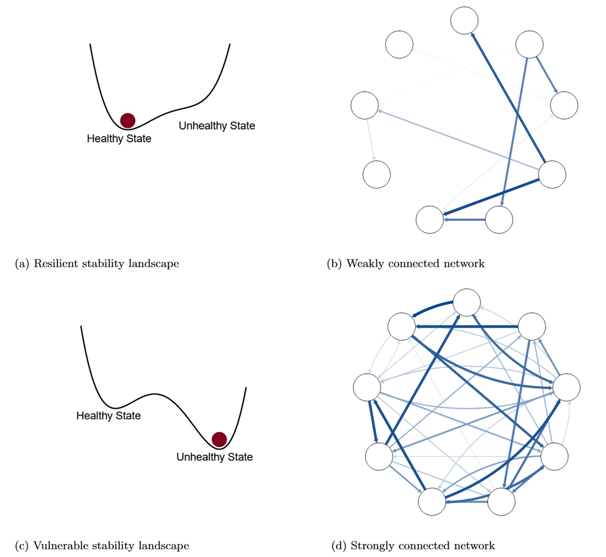

- When does it make sense to assume that a higher density is “bad”?

Hoekstra, Ron, et al. (2024)

## Centrality/Density: Consider Uncertainty

[figure not shown]

`tsnet`: Siepe et al. (2024)

## Prediction

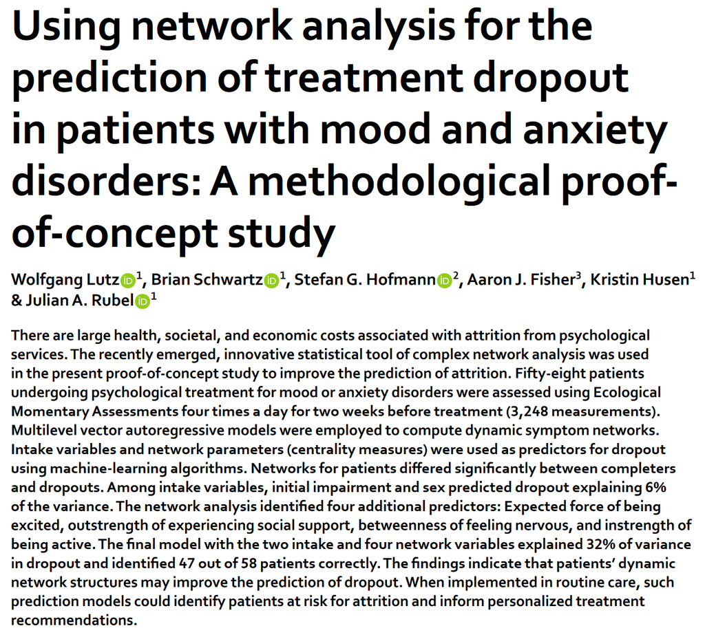

Lutz et al. (2018)

## Prediction

- Johal and Rhemtulla (2024):
  - Using network-derived metrics to predict an outcome
  - Network features did not work very well
- Schumacher, Klein, et al. (2024)
  - Using pairwise symptom associations and centrality to predict an outcome

**Tip**

Start simple instead of complicated (Bringmann 2024)

It is hard to beat the mean (Dejonckheere et al. 2019)

## Which analyses?

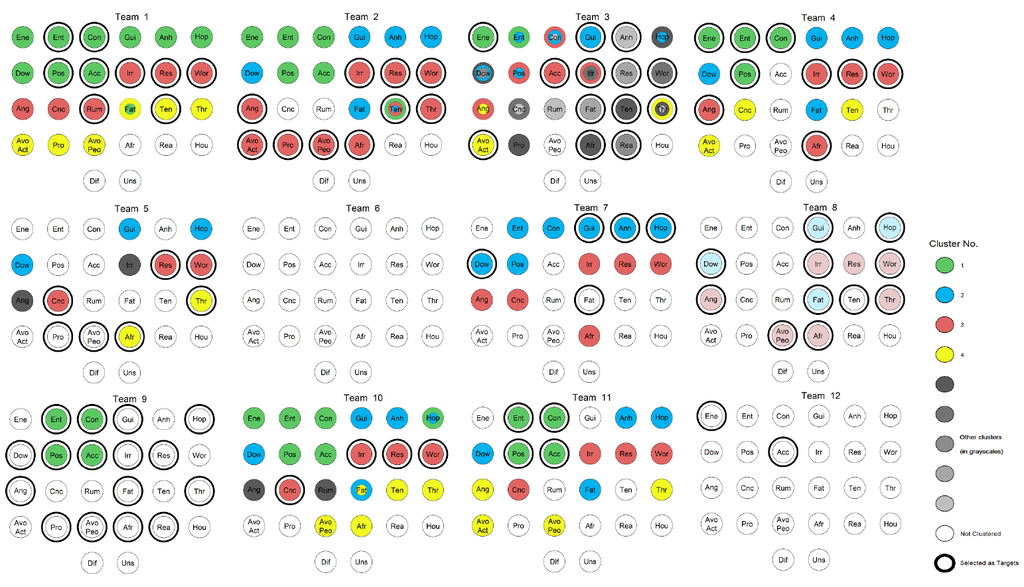

Bastiaansen et al. (2020)

## Analytic uncertainty: Go multiverse

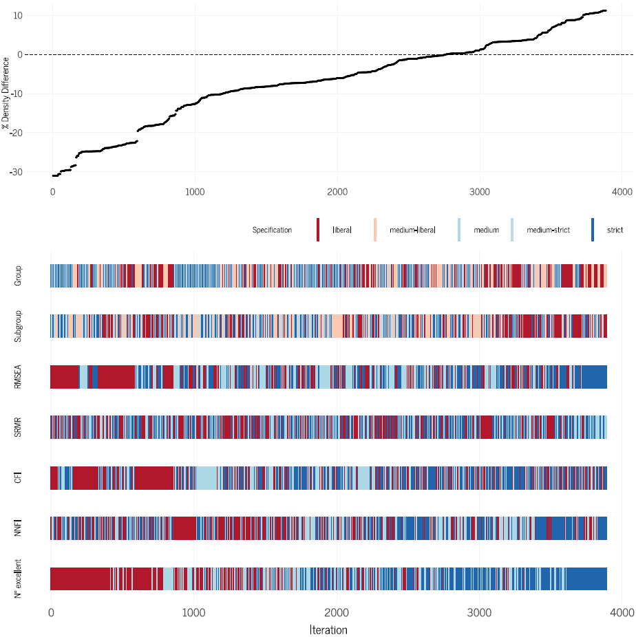

Siepe & Heck (2023)

## Which analyses? Consider Theory

> What is the VAR-based network representing, and what hypotheses are we testing with it? […] can be more explicit about which connections in the network are to be expected and which are contrary to previous knowledge (Bringmann 2021)

[figure not shown]

Come up with strong tests:

- compare network models with simpler models
- compare network feedback with placebo/simpler feedback
- compare network centrality with simpler features

# Summary

## Outlook

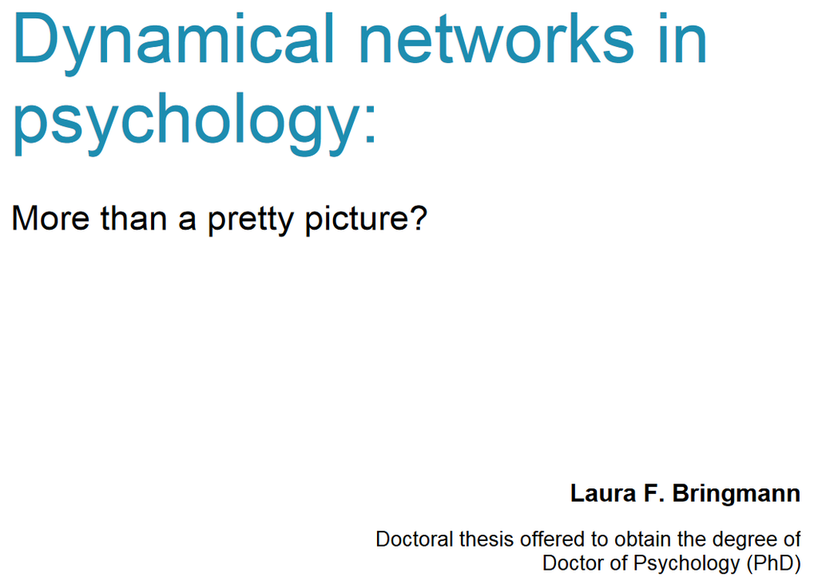

## Main Takeaways

1. Networks are conceptually attractive
2. Longitudinal data give us new information … but also new problems
3. High diversity in network approaches
4. Evidence of utility is still scarce
5. Embrace simplicity and uncertainty

**Questions or Comments?** 💡

## Get in Touch

[Feel](https://bsiepe.github.io/)

[free](https://twitter.com/b_siepe)

[to](https://fediscience.org/@bsiepe)

contact

[me](https://github.com/bsiepe)

[:)](https://bsky.app/profile/bsiepe.bsky.social)

bjoern.siepe@uni-marburg.de

[figure not shown]

# Resources

## Materials

[PNAWS 2020](https://osf.io/hcd8u/) - freely accessible. Partly served as inspiration for this workshop, especially the slides by Julian Burger.

[Psych Networks Blog](https://psych-networks.com/) - no longer active, but interesting backlog

[Workshops by Noémi Schuurman](https://www.nkschuurman.com/workshops.html) - multiple materials for multilevel models in R and MPlus

[Applied Workshop by Me](https://github.com/bsiepe/dynamical-networks-workshop/tree/main/Anwendungs_Workshop_FFM_23) - slides including more code examples etc.

## Figures

Jeremykemp at English Wikipedia (https://commons.wikimedia.org/wiki/File:Gartner_Hype_Cycle.svg), „Gartner Hype Cycle”, https://creativecommons.org/licenses/by-sa/3.0/legalcode

Foto von [Sabina](https://unsplash.com/@sabina_ciesielska?utm_source=unsplash&utm_medium=referral&utm_content=creditCopyText) auf [Unsplash](https://unsplash.com/de/fotos/0zAHoJ1gnGg?utm_source=unsplash&utm_medium=referral&utm_content=creditCopyText)

Foto von [Jonas Leupe](https://unsplash.com/@jonasleupe?utm_source=unsplash&utm_medium=referral&utm_content=creditCopyText) auf [Unsplash](https://unsplash.com/de/fotos/wK-elt11pF0?utm_source=unsplash&utm_medium=referral&utm_content=creditCopyText)

[Rumination icons created by Freepik - Flaticon](https://www.flaticon.com/free-icons/rumination)

Shiny App Screenshot from https://gitlab.kuleuven.be/ppw-okpiv/researchers/u0148925/shinyapp-paa_var_n1

Hehe GIF from [giphy](https://i.giphy.com/media/v1.Y2lkPTc5MGI3NjExNDN4d3BxN3F2ZnVrYjFzNnV3b2Q4bnEwc2JzdmlzcG8zYjF0NHJ2eiZlcD12MV9pbnRlcm5hbF9naWZfYnlfaWQmY3Q9Zw/B0vFTrb0ZGDf2/giphy.gif)

Treadmill GIF from [tenor](https://tenor.com/de/view/fitness-workout-silly-treadmill-gif-8663454)

Regression Meme created with [ImgFlip](https://imgflip.com/memegenerator/)

## References

Bastiaansen, Jojanneke A., Yoram K. Kunkels, Frank J. Blaauw, Steven M. Boker, Eva Ceulemans, Meng Chen, Sy-Miin Chow, et al. 2020. “Time to Get Personal? The Impact of Researchers Choices on the Selection of Treatment Targets Using the Experience Sampling Methodology.” *Journal of Psychosomatic Research* 137 (October): 110211. https://doi.org/10.1016/j.jpsychores.2020.110211.

Beltz, Adriene M., Aidan G. C. Wright, Briana N. Sprague, and Peter C. M. Molenaar. 2016. “Bridging the Nomothetic and Idiographic Approaches to the Analysis of Clinical Data.” *Assessment* 23 (4): 447–58. https://doi.org/10.1177/1073191116648209.

Berkhout, Sophie W., Noémi Katalin Schuurman, and Ellen Hamaker. 2024. “Let Sleeping Dogs Lie? How to Deal with the Night Gap Problem in ESM Data.” May 28, 2024. https://doi.org/10.31234/osf.io/2hec8.

Bringmann, Laura F. 2021. “Person-Specific Networks in Psychopathology: Past, Present, and Future.” *Current Opinion in Psychology*, Psychopathology, 41 (October): 59–64. https://doi.org/10.1016/j.copsyc.2021.03.004.

———. 2024. “The Future of Dynamic Networks in Research and Clinical Practice.” *World Psychiatry* 23 (2): 288–89. https://doi.org/10.1002/wps.21209.

Bringmann, Laura F., Casper Albers, Claudi Bockting, Denny Borsboom, Eva Ceulemans, Angélique Cramer, Sacha Epskamp, et al. 2022. “Psychopathological Networks: Theory, Methods and Practice.” *Behaviour Research and Therapy* 149 (February): 104011. https://doi.org/10.1016/j.brat.2021.104011.

Burger, Julian, Vida Andikkhash, Nelly Jäger, Therese Anderbro, Tessa F. Blanken, and Lars Klintwall. 2024. “A Novel Approach for Constructing Personalized Networks from Longitudinal Perceived Causal Relations.” *Behaviour Research and Therapy* 173 (February): 104456. https://doi.org/10.1016/j.brat.2023.104456.

Burger, Julian, Sacha Epskamp, Date C. van der Veen, Fabian Dablander, Robert A. Schoevers, Eiko I. Fried, and Harriëtte Riese. 2022. “A Clinical PREMISE for Personalized Models: Toward a Formal Integration of Case Formulations and Statistical Networks.” *Journal of Psychopathology and Clinical Science* 131 (8): 906–16. https://doi.org/10.1037/abn0000779.

Dejonckheere, Egon, Merijn Mestdagh, Marlies Houben, Isa Rutten, Laura Sels, Peter Kuppens, and Francis Tuerlinckx. 2019. “Complex Affect Dynamics Add Limited Information to the Prediction of Psychological Well-Being.” *Nature Human Behaviour* 3 (5): 478–91. https://doi.org/10.1038/s41562-019-0555-0.

Epskamp, Sacha, Claudia D. van Borkulo, Date C. van der Veen, Michelle N. Servaas, Adela-Maria Isvoranu, Harriëtte Riese, and Angélique O. J. Cramer. 2018. “Personalized Network Modeling in Psychopathology: The Importance of Contemporaneous and Temporal Connections.” *Clinical Psychological Science* 6 (3): 416–27. https://doi.org/10.1177/2167702617744325.

Frumkin, Madelyn R., Marilyn L. Piccirillo, Emorie D. Beck, Jason T. Grossman, and Thomas L. Rodebaugh. 2021. “Feasibility and Utility of Idiographic Models in the Clinic: A Pilot Study.” *Psychotherapy Research* 31 (4): 520–34. https://doi.org/10.1080/10503307.2020.1805133.

Hall, Mila, Annika A. Wagner, Paloma Scherner, Katharina L. Michael, Glenn Lawyer, Wolfgang Lutz, and Julian Rubel. 2022. “Using Personalized Assessment and Network Model Feedback in Psychotherapy: Proof of Principle for the TheraNet Project.” October 24, 2022. https://doi.org/10.31234/osf.io/8deyj.

Hamaker, E. L., T. Asparouhov, A. Brose, F. Schmiedek, and B. Muthén. 2018. “At the Frontiers of Modeling Intensive Longitudinal Data: Dynamic Structural Equation Models for the Affective Measurements from the Cogito Study.” *Multivariate Behavioral Research* 53 (6): 820–41. https://doi.org/10.1080/00273171.2018.1446819.

Haslbeck, Jonas M. B., Laura F. Bringmann, and Lourens J. Waldorp. 2021. “A Tutorial on Estimating Time-Varying Vector Autoregressive Models.” *Multivariate Behavioral Research* 56 (1): 120–49. https://doi.org/10.1080/00273171.2020.1743630.

Hoekstra, Ria H. A., Sacha Epskamp, and Denny Borsboom. 2022. “Heterogeneity in Individual Network Analysis: Reality or Illusion?” *Multivariate Behavioral Research* 58 (4): 762–86. https://doi.org/10.1080/00273171.2022.2128020.

Hoekstra, Ria H. A., Sacha Epskamp, Andrew A. Nierenberg, Denny Borsboom, and Richard J. McNally. 2024. “Testing Similarity in Longitudinal Networks: The Individual Network Invariance Test (INIT).” *Psychological Methods* Online First Publication (April). https://doi.org/10.1037/met0000638.

Hoekstra, Ria H. A., Jill de Ron, Sacha Epskamp, Donald Robinaugh, and Denny Borsboom. 2024. “Mapping the Dynamics of Idiographic Network Models to the Network Theory of Psychopathology Using Stability Landscapes.” October 11, 2024. https://doi.org/10.31234/osf.io/9sguw.

Johal, Simran K., and Mijke Rhemtulla. 2024. “Relating Network-Instantiated Constructs to Psychological Variables Through Network-Derived Metrics: An Exploratory Study.” *Advances.in/Psychology* 2 (September): e939409. https://doi.org/10.56296/aip00024.

Jordan, D. Gage, E. Samuel Winer, and Taban Salem. 2020. “The Current Status of Temporal Network Analysis for Clinical Science: Considerations as the Paradigm Shifts?” *Journal of Clinical Psychology* 76 (9): 1591–1612. https://doi.org/10.1002/jclp.22957.

Klintwall, Lars, Martin Bellander, and Matti Cervin. 2021. “Perceived Causal Problem Networks: Reliability, Central Problems, and Clinical Utility for Depression.” *Assessment*, September, 10731911211039281. https://doi.org/10.1177/10731911211039281.

Lafit, Ginette, Kristof Meers, and Eva Ceulemans. 2021. “A Systematic Study into the Factors That Affect the Predictive Accuracy of Multilevel VAR(1) Models.” *Psychometrika* 87 (2): 432–76. https://doi.org/10.1007/s11336-021-09803-z.

Levinson, Cheri A., Brenna M. Williams, Caroline Christian, Rowan A. Hunt, Ani C. Keshishian, Leigh C. Brosof, Irina A. Vanzhula, et al. 2023. “Personalizing Eating Disorder Treatment Using Idiographic Models: An Open Series Trial.” *Journal of Consulting and Clinical Psychology* 91 (1): 14–28. https://doi.org/10.1037/ccp0000785.

Lutz, Wolfgang, Brian Schwartz, Stefan G. Hofmann, Aaron J. Fisher, Kristin Husen, and Julian A. Rubel. 2018. “Using Network Analysis for the Prediction of Treatment Dropout in Patients with Mood and Anxiety Disorders: A Methodological Proof-of-Concept Study.” *Scientific Reports* 8 (1, 1): 7819. https://doi.org/10.1038/s41598-018-25953-0.

Mansueto, Alessandra C., Reinout W. Wiers, Julia C. M. van Weert, Barbara C. Schouten, and Sacha Epskamp. 2023. “Investigating the Feasibility of Idiographic Network Models.” *Psychological Methods* 28 (5): 1052–68. https://doi.org/10.1037/met0000466.supp.

Marsman, Maarten, and Mijke Rhemtulla. 2022. “Guest Editors’ Introduction to The Special Issue ‘Network Psychometrics in Action’: Methodological Innovations Inspired by Empirical Problems.” *Psychometrika* 87 (1): 1–11. https://doi.org/10.1007/s11336-022-09861-x.

Revol, Jordan, Ginette Lafit, and Eva Ceulemans. 2024. “A New Sample-Size Planning Approach for Person-Specific VAR(1) Studies: Predictive Accuracy Analysis.” *Behavior Research Methods* 56 (7): 7152–67. https://doi.org/10.3758/s13428-024-02413-4.

Ryan, Oisín, and Ellen L. Hamaker. 2022. “Time to Intervene: A Continuous-Time Approach to Network Analysis and Centrality.” *Psychometrika* 87 (1): 214–52. https://doi.org/10.1007/s11336-021-09767-0.

Ryan, Oisín, Jonas M. B. Haslbeck, and Lourens Waldorp. 2023. “Non-Stationarity in Time-Series Analysis: Modeling Stochastic and Deterministic Trends.” July 13, 2023. https://doi.org/10.31234/osf.io/z7ja2.

Scholten, Saskia, Julian Rubel, Julia Glombiewski, and Christopher Milde. 2023. “What Time-Varying Network Models Based on Functional Analysis Tell Us about the Course of a Patient’s Problem.” *OSF Preprints*, May. https://doi.org/10.31219/osf.io/gz3c2.

Schumacher, Lea, Julian Burger, Jette Echterhoff, and Levente Kriston. 2024. “Methodological and Statistical Practices of Using Symptom Networks to Evaluate Mental Health Interventions: A Review and Reflections.” *Multivariate Behavioral Research* 59 (4): 663–76. https://doi.org/10.1080/00273171.2024.2335401.

Schumacher, Lea, Jan Philipp Klein, Martin Hautzinger, Martin Härter, Elisabeth Schramm, and Levente Kriston. 2024. “Predicting the Outcome of Psychotherapy for Chronic Depression by Person-Specific Symptom Networks.” *World Psychiatry* 23 (3): 411–20. https://doi.org/10.1002/wps.21241.

Siepe, Björn Sebastian, Christian Sander, Martin Schultze, Andreas Kliem, Sascha Ludwig, Ulrich Hegerl, and Hanna Reich. 2024. “Time-Varying Network Models for the Temporal Dynamics of Depressive Symptomatology in Patients With Depressive Disorders: Secondary Analysis of Longitudinal Observational Data.” *JMIR Mental Health* 11 (April): e50136. https://doi.org/10.2196/50136.

Siepe, Björn S., and Daniel W. Heck. 2023. “Multiverse Analysis for Dynamic Network Models: Investigating the Influence of Plausible Alternative Modeling Choices.” November 16, 2023. https://doi.org/10.31219/osf.io/etm3u.

Siepe, Björn S., Matthias Kloft, and Daniel W. Heck. 2024. “Bayesian Estimation and Comparison of Idiographic Network Models.” February 23, 2024. https://doi.org/10.31234/osf.io/uwfjc.